# Table of Contents

Este obra está licenciado com uma Licença [Creative Commons Atribuição-CompartilhaIgual 3.0 Brasil](http://creativecommons.org/licenses/by-sa/3.0/br/).

# *Trabalho de Cálculo de Propriedades Geométricas de Seções Abertas de Paredes Finas*

## *EEA 528 - Estruturas de Aço II*

###### João Pedro Nunes Cavalcante DRE: 116082493

###### Algumas Bibliotecas utilizadas ao longo deste código

```python
import numpy as np
import matplotlib.pyplot as plt
# from jupyterthemes import jtplot as jt
from scipy.integrate import quad
from ipywidgets import Layout, FloatText, interactive
# jt.style(theme="gruvboxd")
```

# Criação do Código

## Definição da Geometria

### Dados da seção

```python
Nodes = np.array([
    #  unit = mm
    #  [X coord, Y coord]
    [67.300, 83.650],
    [67.300, 90.475],
    [67.300, 97.300],
    [50.475, 97.300],
    [33.650, 97.300],
    [16.825, 97.300],
    [0.000, 97.300],
    [0.000, 81.083],
    [0.000, 64.867],
    [0.000, 48.650],
    [0.000, 32.433],
    [0.000, 16.217],
    [0.000, 0.000],
    [16.825, 0.000],
    [33.650, 0.000],
    [50.475, 0.000],
    [67.300, 0.000],
    [67.300, 6.825],
    [67.300, 13.650]])
```

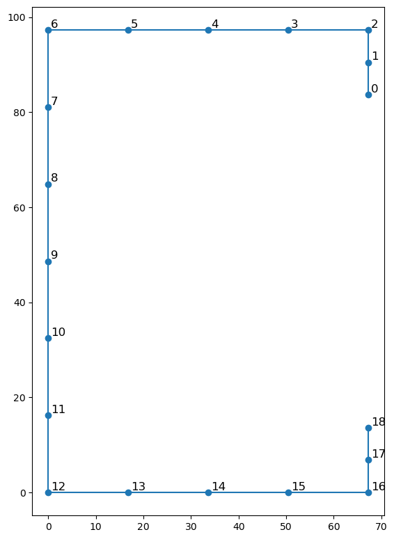

```python
plt.figure(figsize=(9.5, 9.5))
plt.plot(Nodes[:, 0], Nodes[:, 1], marker="o")
plt.gca().set_aspect('equal')
for i in range(0, len(Nodes)):
    plt.text(Nodes[i, 0]+.5, Nodes[i, 1]+.5, i, fontsize=12)
```

```python
t = 2.7  # thickness
```

## Discretização dos segmentos que formam a seção

[figure not shown]

$i$ $-$ Nó inicial;  
$j$ $-$ Nó final;  
$c$ $-$ Centroide;  
$s$ $-$ Direção do eixo local;  
$x_{i},y_{i}$ $-$ Coordenadas do nó inicial;  
$x_{j},y_{j}$ $-$ Coordenadas do nó final;  
$x_{c},y_{c}$ $-$ Coordenadas do centroide;  
$\theta$ $-$ Ângulo que o segmento faz com o eixo $x$ em relação ao eixo local $s$;  
$l$ $-$ Comprimento do segmento;  
$t$ $-$ Espessura do segmento;

## Centroide da Seção

```python
def Centroide(Nodes):
    return np.sum([np.sqrt(np.sum((Nodes[i]-Nodes[i+1])**2))*(Nodes[i]+Nodes[i+1])/2 for i in range(len(Nodes)-1)], axis=0)/\
        np.sum([np.sqrt(np.sum((Nodes[i]-Nodes[i+1])**2)) for i in range(len(Nodes)-1)])
```

###### Calculando o Centroide dessa seção

```python
c = Centroide(Nodes)
print(c)
```

```
[24.56242284 48.65      ]
```

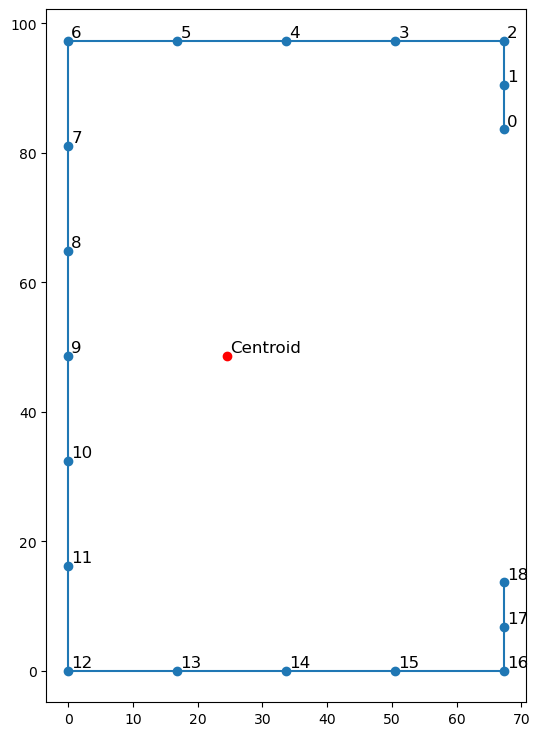

```python
plt.figure(figsize=(9, 9))
plt.plot(Nodes[:, 0], Nodes[:, 1], marker="o")
plt.gca().set_aspect('equal')
c_coord = Centroide(Nodes)
plt.scatter(c_coord[0], c_coord[1], color="Red")
plt.text(c_coord[0]+.5, c_coord[1]+.5, "Centroid", fontsize=12)
for i in range(0, len(Nodes)):
    plt.text(Nodes[i, 0]+.5, Nodes[i, 1]+.5, i, fontsize=12)
```

## Propriedade das Áreas Planas

```python
def Inercia(Nodes, t):
    c = Centroide(Nodes)
    L = np.array([np.sqrt(np.sum((Nodes[i]-Nodes[i+1])**2))
                 for i in range(len(Nodes)-1)])
    trig = np.array([(Nodes[i+1]-Nodes[i])/L[i] for i in range(len(Nodes)-1)])
    A = L*t
    A_sec = np.sum(A)
    cos = trig[:, 0]
    sen = trig[:, 1]
    Ix = np.sum([(1/24)*(t*L[i]**3 + L[i]*t**3) + (1/24)*(t*L[i]**3 - L[i]*t**3)*(sen[i] **
                2 - cos[i]**2) + (1/4)*A[i]*(Nodes[i][1]+Nodes[i+1][1])**2 for i in range(len(Nodes)-1)])
    Iy = np.sum([(1/24)*(t*L[i]**3 + L[i]*t**3) - (1/24)*(t*L[i]**3 - L[i]*t**3)*(sen[i] **
                2 - cos[i]**2) + (1/4)*A[i]*(Nodes[i][0]+Nodes[i+1][0])**2 for i in range(len(Nodes)-1)])
    Ixy = np.sum([(1/24)*(t*L[i]**3 - L[i]*t**3)*2*sen[i]*cos[i] + (1/4)*A[i]*(Nodes[i]
                 [0]+Nodes[i+1][0])*(Nodes[i][1]+Nodes[i+1][1]) for i in range(len(Nodes)-1)])
    J = (1/3)*np.sum(L*t**3)
    return A_sec, J, Ix, Iy, Ixy, c[0], c[1]
```

###### Teste

```python
Inercia(Nodes, t)
```

```
(699.84,
 1700.6111999999998,
 2854118.7616499993,
 882736.5316499999,
 836282.1158999999,
 24.56242283950617,
 48.649999999999984)
```

## Propriedades Setoriais

```python
def Inercias_setoriais(Nodes, t, x_a=0, y_a=0):
    L = np.array([np.sqrt(np.sum((Nodes[i]-Nodes[i+1])**2))
                 for i in range(len(Nodes)-1)])
    trig = np.array([(Nodes[i+1]-Nodes[i])/L[i] for i in range(len(Nodes)-1)])
    A = L*t
    A_sec = np.sum(A)
    cos = trig[:, 0]
    sen = trig[:, 1]

    def func1(i):
        def func(s):
            return (cos[i]*s + Nodes[i][0] - x_a)*sen[i] - (sen[i]*s + Nodes[i][1] - y_a)*cos[i]
        return func
    w = np.array([quad(func1(i), 0, L[i])[0] for i in range(len(L))]).cumsum()
    w_list = np.insert(w, 0, 0)

    def func(i):
        def func0(s):
            return s*(w_list[i+1]-w_list[i])/L[i] + w_list[i]

        def func1(s):
            return (s*(w_list[i+1]-w_list[i])/L[i] + w_list[i])*(cos[i]*s+Nodes[i][0])

        def func2(s):
            return (s*(w_list[i+1]-w_list[i])/L[i] + w_list[i])*(sen[i]*s+Nodes[i][1])

        def func3(s):
            return (s*(w_list[i+1]-w_list[i])/L[i] + w_list[i])**2

        def func4(s):
            return ((cos[i]*s + Nodes[i][0] - x_a)*sen[i] - (sen[i]*s + Nodes[i][1] - y_a)*cos[i])**2
        return func0, func1, func2, func3, func4
    Qwa = t*np.sum([quad(func(i)[0], 0, L[i])[0] for i in range(len(L))])
    Ixwa = t*np.sum([quad(func(i)[1], 0, L[i])[0] for i in range(len(L))])
    Iywa = t*np.sum([quad(func(i)[2], 0, L[i])[0] for i in range(len(L))])
    Iwa = t*np.sum([quad(func(i)[3], 0, L[i])[0] for i in range(len(L))])
    Iha = t*np.sum([quad(func(i)[4], 0, L[i])[0] for i in range(len(L))])
    return w, Qwa, Ixwa, Iywa, Iwa, Iha
```

## Função de Definição das Propriedades Da Seção

```python
def Sec_prop(Nodes, t):
    # Cálculo das coordenadas do centroide
    c = Centroide(Nodes)
    # Levando todos os pontos para o eixo de coordenadas do centroide
    New = Nodes - c
    # Cálculo das Inércias e Inércias setoriais no eixo do centroide
    A_sec, J, Ix, Iy, Ixy, xc, yc = Inercia(New, t)
    w, Qwa, Ixwa, Iywa, Iwa, Iha = Inercias_setoriais(New, t, -c[0], -c[1])  # polo escolhido será o (0,0) do eixo global
    # Cálculo das coordenadas do Centro de Cisalhamento no eixo do centroide
    x_cis_c = -(Ixy*Ixwa-Iy*Iywa)/(Ix*Iy-Ixy**2)-c[0]
    y_cis_c = -(Ix*Ixwa-Ixy*Iywa)/(Ix*Iy-Ixy**2)-c[1]
    # Cálculo das Inércias Setoriais no centro de cisalhamento
    w, Qw, Ixw, Iyw, Iw, Ih = Inercias_setoriais(New, t, x_cis_c, y_cis_c)
    # Cálculo da Constante de Empenamento
    Cw = Iw - (Qw**2)/A_sec - y_cis_c*Ixw + x_cis_c*Iyw
    # Cálculo do centro de cisalhamento no eixo global
    x_cis_g = x_cis_c + c[0]
    y_cis_g = y_cis_c + c[1]
    # Cálculo do ângulo dos eixos principais
    phi = np.arctan(-(2*Ixy)/(Ix - Iy))/2
    # Cálculo das Inércias Principais
    I1 = (Ix+Iy)/2 + (1/2) * np.sqrt((Ix-Iy)**2 + 4*Ixy**2)
    I2 = (Ix+Iy)/2 - (1/2) * np.sqrt((Ix-Iy)**2 + 4*Ixy**2)
    # Cálculo do raio de giração polar da seção bruta em relação ao centro de cisalhamento
    x0 = abs(c[0] - x_cis_g)
    y0 = abs(c[1] - y_cis_g)
    r0 = np.sqrt((Ix+Iy)/A_sec + x0**2 + y0**2)
    # Cálculo do Módulo de resistência elástico da seção bruta em relação aos eixos X e Y
    with np.errstate(divide='ignore'):
        Wx = Ix/(np.max(np.abs(Nodes[:, 1]-c[1])))
        Wy = Iy/(np.max(np.abs(Nodes[:, 0]-c[0])))
    # Cálculo do Módulo de resistência elástico da seção bruta em relação aos eixos principais
    M_rotation = np.array([[np.cos(phi), -np.sin(phi)], [np.sin(phi), np.cos(phi)]])
    Nodes_prin = np.array([np.matmul(M_rotation, New[i]) for i in range(len(New))])
    with np.errstate(divide='ignore'):
        W1 = I1/(np.max(np.abs(Nodes_prin[:, 1])))
        W2 = I2/(np.max(np.abs(Nodes_prin[:, 0])))
    return A_sec, J, Ix, Iy, Ixy, c, Cw, np.degrees(phi), I1, I2, x0, y0, r0, Wx, Wy, W1, W2, [x_cis_g, y_cis_g]
```

## Conclusão

```python
Nodes = np.array([
    #  unit = mm
    #  [X coord, Y coord]
    [67.300, 83.650],
    [67.300, 90.475],
    [67.300, 97.300],
    [50.475, 97.300],
    [33.650, 97.300],
    [16.825, 97.300],
    [0.000, 97.300],
    [0.000, 81.083],
    [0.000, 64.867],
    [0.000, 48.650],
    [0.000, 32.433],
    [0.000, 16.217],
    [0.000, 0.000],
    [16.825, 0.000],
    [33.650, 0.000],
    [50.475, 0.000],
    [67.300, 0.000],
    [67.300, 6.825],
    [67.300, 13.650]])
t = 2.7  # thickness
```

```python
def report(Nodes,t):
    A_sec, J, Ix, Iy, Ixy, c, Cw, phi, I1, I2, x0, y0, r0, Wx, Wy, W1, W2, cis = Sec_prop(Nodes, t)
    print(f'''
    Área da Seção (mm): {round(A_sec,2)}
    Constante Torcional (mm⁴): {round(J,3)}
    Ix (mm⁴): {round(Ix,3)}
    Iy (mm⁴): {round(Iy,3)}
    Ixy (mm): {round(Ixy,3)}
    x centro de torção (mm): {round(cis[0],2)}
    y centro de torção (mm): {round(cis[1],2)}
    Constante de Empenamento: {round(Cw,3)}
    Wx (mm³): {round(Wx,3)}
    Wy (mm³): {round(Wy,3)}
    -------------------------------------------
    x centroide (mm): {round(c[0],2)}
    y centroide (mm): {round(c[1],2)}
    I1 (mm⁴): {round(I1,3)}
    I2 (mm⁴): {round(I2,3)}
    θ (°): {round(phi,2)}
    x0 (mm): {round(x0,2)}
    y0 (mm): {round(y0,2)}
    r0 (mm): {round(r0,3)}
    W1 (mm³): {round(W1,3)}
    W2 (mm³): {round(W2,3)}
    ''')
report(Nodes,t)
```

```
    Área da Seção (mm): 699.84
    Constante Torcional (mm⁴): 1700.611
    Ix (mm⁴): 1197721.703
    Iy (mm⁴): 460514.231
    Ixy (mm): -0.0
    x centro de torção (mm): -33.71
    y centro de torção (mm): 48.63
    Constante de Empenamento: 970246475.829
    Wx (mm³): 24619.151
    Wy (mm³): 10775.394
    -------------------------------------------
    x centroide (mm): 24.56
    y centroide (mm): 48.65
    I1 (mm⁴): 1197721.703
    I2 (mm⁴): 460514.231
    θ (°): 0.0
    x0 (mm): 58.27
    y0 (mm): 0.02
    r0 (mm): 75.93
    W1 (mm³): 24619.151
    W2 (mm³): 10775.394
```

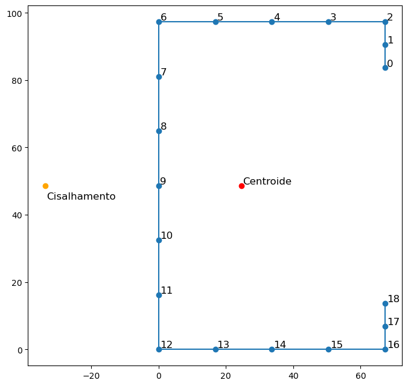

```python
def plot(Nodes, t):
    _, _, _, _, _, c_coord, _, _, _, _, _, _, _, _, _, _, _, cis_coord = Sec_prop(Nodes, t)
    plt.figure(figsize=(8, 8))
    plt.plot(Nodes[:, 0], Nodes[:, 1], marker="o", label="Nós da Seção")
    plt.gca().set_aspect('equal')
    plt.scatter(c_coord[0], c_coord[1], color="Red", label="Centroide")
    plt.scatter(cis_coord[0], cis_coord[1], color="Orange",
                label="Centro de Cisalhamento", zorder=10)
    plt.text(c_coord[0]+.5, c_coord[1]+.5, "Centroide", fontsize=12)
    plt.text(cis_coord[0]+.5, cis_coord[1]-4, "Cisalhamento", fontsize=12)
    for i in range(0, len(Nodes)):
        plt.text(Nodes[i, 0]+.5, Nodes[i, 1]+.5, i, fontsize=12)
    return


plot(Nodes, t)
```

# Questão 1

## a) Perfil Cantoneira de abas desiguais L100x50x2 (mm)

```python
Nodes = np.array([
    #  unit = mm
    #  [X coord, Y coord]
    [0.0000, 100.0000],
    [0.0000, 83.3333],
    [0.0000, 66.6667],
    [0.0000, 50.0000],
    [0.0000, 33.3333],
    [0.0000, 16.6667],
    [0.0000, 0.0000],
    [12.5000, 0.0000],
    [25.0000, 0.0000],
    [37.5000, 0.0000],
    [50.0000, 0.0000]])
t = 2.0  # thickness
```

```python
report(Nodes,t)
```

```
    Área da Seção (mm): 300.0
    Constante Torcional (mm⁴): 400.0
    Ix (mm⁴): 333366.667
    Iy (mm⁴): 62566.667
    Ixy (mm): -83333.333
    x centro de torção (mm): 0.0
    y centro de torção (mm): 0.0
    Constante de Empenamento: 0.0
    Wx (mm³): 5000.5
    Wy (mm³): 1501.6
    -------------------------------------------
    x centroide (mm): 8.33
    y centroide (mm): 33.33
    I1 (mm⁴): 356955.988
    I2 (mm⁴): 38977.345
    θ (°): 15.81
    x0 (mm): 8.33
    y0 (mm): 33.33
    r0 (mm): 50.003
    W1 (mm³): 5768.852
    W2 (mm³): 792.7
```

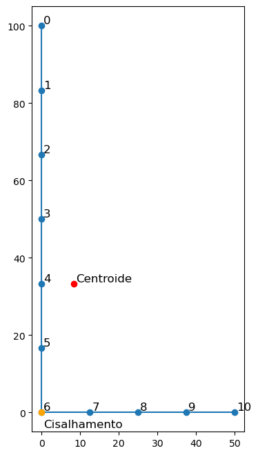

```python
plot(Nodes, t)
```

[figure not shown]

## b) Perfil Ue 200x100x20x2 (mm)

```python
Nodes = np.array([
    #  unit = mm
    #  [X coord, Y coord]
    [100.0000, 180.0000],
    [100.0000, 190.0000],
    [100.0000, 200.0000],
    [83.3333, 200.0000],
    [66.6667, 200.0000],
    [50.0000, 200.0000],
    [33.3333, 200.0000],
    [16.6667, 200.0000],
    [0.0000, 200.0000],
    [0.0000, 175.0000],
    [0.0000, 150.0000],
    [0.0000, 125.0000],
    [0.0000, 100.0000],
    [0.0000, 75.0000],
    [0.0000, 50.0000],
    [0.0000, 25.0000],
    [0.0000, 0.0000],
    [16.6667,  0.0000],
    [33.3333,  0.0000],
    [50.0000,  0.0000],
    [66.6667,  0.0000],
    [83.3333,  0.0000],
    [100.0000, 0.0000],
    [100.0000, 10.0000],
    [100.0000, 20.0000]])
t = 2.0  # thickness
```

```python
report(Nodes,t)
```

```
    Área da Seção (mm): 880.0
    Constante Torcional (mm⁴): 1173.333
    Ix (mm⁴): 5984133.333
    Iy (mm⁴): 1242584.242
    Ixy (mm): 0.0
    x centro de torção (mm): -46.61
    y centro de torção (mm): 99.99
    Constante de Empenamento: 10038514779.488
    Wx (mm³): 59841.333
    Wy (mm³): 18224.569
    -------------------------------------------
    x centroide (mm): 31.82
    y centroide (mm): 100.0
    I1 (mm⁴): 5984133.333
    I2 (mm⁴): 1242584.242
    θ (°): -0.0
    x0 (mm): 78.43
    y0 (mm): 0.01
    r0 (mm): 119.848
    W1 (mm³): 59841.333
    W2 (mm³): 18224.569
```

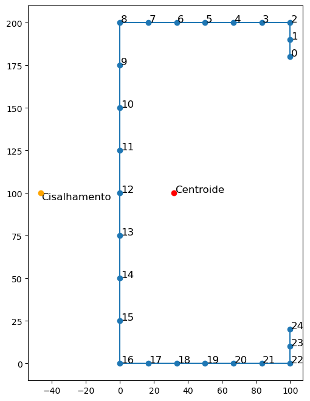

```python
plot(Nodes, t)
```

[figure not shown]

## c) Perfil Rack 100x30x20x25x2 ângulo de 60º (mm)

```python
Nodes = np.array([
    #  unit = mm
    #  [X coord, Y coord]
    [65.0000, 82.6795],
    [52.5000, 82.6795],
    [40.0000, 82.6795],
    [35.0000, 91.3397],
    [30.0000, 100.0000],
    [22.5000, 100.0000],
    [15.0000, 100.0000],
    [7.5000, 100.0000],
    [0.0000, 100.0000],
    [0.0000, 83.3333],
    [0.0000, 66.6667],
    [0.0000, 50.0000],
    [0.0000, 33.3333],
    [0.0000, 16.6667],
    [0.0000, 0.0000],
    [7.5000, 0.0000],
    [15.0000, 0.0000],
    [22.5000, 0.0000],
    [30.0000, 0.0000],
    [35.0000, 8.6603],
    [40.0000, 17.3205],
    [52.5000, 17.3205],
    [65.0000, 17.3205]])
t = 2.0  # thickness
```

```python
report(Nodes,t)
```

```
    Área da Seção (mm): 500.0
    Constante Torcional (mm⁴): 666.667
    Ix (mm⁴): 712259.541
    Iy (mm⁴): 221541.633
    Ixy (mm): 0.0
    x centro de torção (mm): -28.92
    y centro de torção (mm): 49.98
    Constante de Empenamento: 687389741.202
    Wx (mm³): 14245.191
    Wy (mm³): 4890.544
    -------------------------------------------
    x centroide (mm): 19.7
    y centroide (mm): 50.0
    I1 (mm⁴): 712259.541
    I2 (mm⁴): 221541.633
    θ (°): -0.0
    x0 (mm): 48.62
    y0 (mm): 0.02
    r0 (mm): 65.049
    W1 (mm³): 14245.191
    W2 (mm³): 4890.544
```

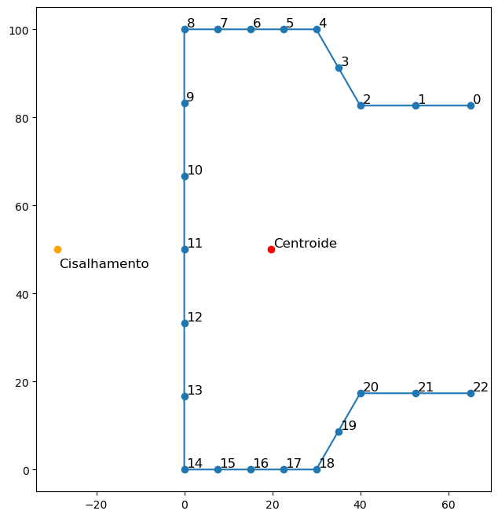

```python
plot(Nodes, t)
```

[figure not shown]

## d) Perfil Assimétrico

```python
Nodes = np.array([
    #  unit = mm
    #  [X coord, Y coord]
    [50.0000, 120.0000],
    [50.0000, 135.0000],
    [50.0000, 150.0000],
    [37.5000, 150.0000],
    [25.0000, 150.0000],
    [12.5000, 150.0000],
    [0.0000, 150.0000],
    [0.0000, 131.2500],
    [0.0000, 112.5000],
    [0.0000, 93.7500],
    [0.0000, 75.0000],
    [0.0000, 56.2500],
    [0.0000, 37.5000],
    [0.0000, 18.7500],
    [0.0000, 0.0000],
    [15.0000, 0.0000],
    [30.0000, 0.0000],
    [30.0000, 12.5000],
    [30.0000, 25.0000]])
t = 2.0  # thickness
```

```python
report(Nodes,t)
```

```
    Área da Seção (mm): 570.0
    Constante Torcional (mm⁴): 760.0
    Ix (mm⁴): 1859784.693
    Iy (mm⁴): 186978.772
    Ixy (mm): 158087.719
    x centro de torção (mm): -18.81
    y centro de torção (mm): 117.21
    Constante de Empenamento: 783248880.211
    Wx (mm³): 22932.986
    Wy (mm³): 5173.684
    -------------------------------------------
    x centroide (mm): 13.86
    y centroide (mm): 81.1
    I1 (mm⁴): 1874593.598
    I2 (mm⁴): 172169.867
    θ (°): -5.35
    x0 (mm): 32.67
    y0 (mm): 36.12
    r0 (mm): 77.216
    W1 (mm³): 22791.865
    W2 (mm³): 4059.726
```

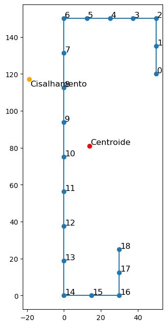

```python
plot(Nodes, t)
```

[figure not shown]

## Conclusão

# Questão 2

## a)

- Propriedades Geométricas da Seção Rack do tópico 8.3

[figure not shown]

- Flambagem Local

[figure not shown]

Podemos notar que o modo de instabilidade acima é o local, caracterizado pelas distorções sem deslocamento dos vérticies das paredes que compõem a seção. O valor de força normal de compreção crítica é de $205,1 kN$ com um comprimento de instabilidade de $77,84 mm$;

- Flambagem distorcional

[figure not shown]

- Flambagem Flexo-Torção

[figure not shown]

Podemos notar que o modo de instabilidade acima é o global, caracterizado pela distorção do membro sem distorção da seção transversal, somente com translação e/ou rotação da seção transversal. O valor de força normal de compreção crítica é de $26,05 kN$ e o comprimento de instabilidade é $> 4000mm$.

## b)

- Propriedades Geométricas da Seção Rack do tópico 8.3 com momento no eixo de maior inércia

[figure not shown]

- Flambagem Local

[figure not shown]

Podemos notar que o modo de instabilidade acima é o local, caracterizado pelas distorções sem deslocamento dos vérticies das paredes que compõem a seção. O valor de força normal de compreção crítica é de $23790 kN.mm$ com um comprimento de instabilidade de $52,26 mm$;

- Flambagem distorcional

[figure not shown]

Podemos notar que o modo de instabilidade acima é o distorcional, caracterizado tanto pelas distorção de paredes simultâneo a translação de linhas de interseção de elementos de paredes adjacentes. O valor de força normal de compreção crítica é de $8776 kN.mm$ e o comprimento de instabilidade é de $350,58mm$, intermediario entre os comprimentos locais e o globais;

- Flambagem Flexo-Torção

[figure not shown]

Podemos notar que o modo de instabilidade acima é o global, caracterizado pela distorção do membro sem distorção da seção transversal, somente com translação e/ou rotação da seção transversal. O valor de força normal de compreção crítica é de $1923 kN.mm$ e o comprimento de instabilidade é $> 4000mm$.

## c)

### Compressão axial

- Propriedades Geométricas da Seção Rack do tópico 8.3

[figure not shown]

- Flambagem Local

[figure not shown]

Podemos notar que o modo de instabilidade acima é o local, caracterizado pelas distorções sem deslocamento dos vérticies das paredes que compõem a seção. O valor de força normal de compreção crítica é de $297,7 kN$ com um comprimento de instabilidade de $115,93 mm$;

- Flambagem distorcional

[figure not shown]

Podemos notar que o modo de instabilidade acima é o distorcional, caracterizado tanto pelas distorção de paredes simultâneo a translação de linhas de interseção de elementos de paredes adjacentes. O valor de força normal de compreção crítica é de $255,4 kN$ e o comprimento de instabilidade é de $596,30mm$, intermediario entre os comprimentos locais e o globais;

- Flambagem Flexo-Torção

[figure not shown]

Podemos notar que o modo de instabilidade acima é o global, caracterizado pela distorção do membro sem distorção da seção transversal, somente com translação e/ou rotação da seção transversal. O valor de força normal de compreção crítica é de $83,6 kN$ e o comprimento de instabilidade é $> 4000mm$.

### Flexão no Eixo de Maior Inércia

- Propriedades Geométricas da Seção Rack do tópico 8.3

[figure not shown]

- Flambagem Local

[figure not shown]

Podemos notar que o modo de instabilidade acima é o local, caracterizado pelas distorções sem deslocamento dos vérticies das paredes que compõem a seção. O valor de força normal de compreção crítica é de $32890 kN.mm$ com um comprimento de instabilidade de $81,36 mm$;

- Flambagem distorcional

[figure not shown]

Podemos notar que o modo de instabilidade acima é o distorcional, caracterizado tanto pelas distorção de paredes simultâneo a translação de linhas de interseção de elementos de paredes adjacentes. O valor de força normal de compreção crítica é de $14240 kN.mm$ e o comprimento de instabilidade é de $545,78mm$, intermediario entre os comprimentos locais e o globais;

- Flambagem Flexo-Torção

[figure not shown]

Podemos notar que o modo de instabilidade acima é o global, caracterizado pela distorção do membro sem distorção da seção transversal, somente com translação e/ou rotação da seção transversal. O valor de força normal de compreção crítica é de $6816 kN.mm$ e o comprimento de instabilidade é $> 4000mm$.

### Conclusão

Podemos perceber que a mudança de restrição teve um grande impacto nos modos de flambagem tanto nos comprimentos quanto nos valores de compressão ou de momento admissíveis. Isso pode ser explicado já que a mudança de um simples apoio para um bi engastado diminui o comprimento efetivo de flambagem, o que torna a viga, em teoria, menos esbelta. Essa constatação é ainda mais notavel nos modos globais comparados aos locais e distorcionais.